# Supervised Learning Project - Thera Bank Personal Loan (Banking)

**Attribute Information:**

- ID : Customer ID
- Age : Customer's age in completed years
- Experience : #years of professional experience
- Income : Annual income of the customer
- ZIP Code : Home Address ZIP code.
- Family : Family size of the customer
- CCAvg : Avg. spending on credit cards per month
- Education : Education Level.
  1. Undergrad
  2. Graduate
  3. Advanced/Professional
- Mortgage : Value of house mortgage if any.
- Personal Loan : Did this customer accept the personal loan offered in the last campaign?
- Securities Account : Does the customer have a securities account with the bank?
- CD Account : Does the customer have a certificate of deposit (CD) account with the bank?
- Online : Does the customer use internet banking facilities?
- Credit card : Does the customer use a credit card issued by UniversalBank?

## 1. Import the libraries

```python
import numpy as np
import pandas as pd
import matplotlib.pyplot as plt
%matplotlib inline
import seaborn as sns
from sklearn.model_selection import train_test_split
from sklearn.linear_model import LogisticRegression
from sklearn.naive_bayes import GaussianNB
from sklearn.neighbors import KNeighborsClassifier
from sklearn.svm import SVC
from sklearn.metrics import confusion_matrix, accuracy_score, classification_report, roc_auc_score, roc_curve
from sklearn.preprocessing import StandardScaler
import warnings
warnings.filterwarnings('ignore')
```

## 2. Exploratory data analysis

```python
dataset = pd.read_csv('Bank_Personal_Loan_Modelling.csv')
dataset.head()
```

|  | ID | Age | Experience | Income | ZIP Code | Family | CCAvg | Education | Mortgage | Personal Loan | Securities Account | CD Account | Online | CreditCard |
| --- | --- | --- | --- | --- | --- | --- | --- | --- | --- | --- | --- | --- | --- | --- |
| 0 | 1 | 25 | 1 | 49 | 91107 | 4 | 1.6 | 1 | 0 | 0 | 1 | 0 | 0 | 0 |
| 1 | 2 | 45 | 19 | 34 | 90089 | 3 | 1.5 | 1 | 0 | 0 | 1 | 0 | 0 | 0 |
| 2 | 3 | 39 | 15 | 11 | 94720 | 1 | 1.0 | 1 | 0 | 0 | 0 | 0 | 0 | 0 |
| 3 | 4 | 35 | 9 | 100 | 94112 | 1 | 2.7 | 2 | 0 | 0 | 0 | 0 | 0 | 0 |
| 4 | 5 | 35 | 8 | 45 | 91330 | 4 | 1.0 | 2 | 0 | 0 | 0 | 0 | 0 | 1 |

#### Shape of the data

```python
print('Rows in the dataset:', dataset.shape[0])
print('Columns in the dataset:', dataset.shape[1])
```

```
Rows in the dataset: 5000
Columns in the dataset: 14
```

#### Data Types of each columns

```python
dataset.info()
```

```
<class 'pandas.core.frame.DataFrame'>
RangeIndex: 5000 entries, 0 to 4999
Data columns (total 14 columns):
 #   Column              Non-Null Count  Dtype
---  ------              --------------  -----
 0   ID                  5000 non-null   int64
 1   Age                 5000 non-null   int64
 2   Experience          5000 non-null   int64
 3   Income              5000 non-null   int64
 4   ZIP Code            5000 non-null   int64
 5   Family              5000 non-null   int64
 6   CCAvg               5000 non-null   float64
 7   Education           5000 non-null   int64
 8   Mortgage            5000 non-null   int64
 9   Personal Loan       5000 non-null   int64
 10  Securities Account  5000 non-null   int64
 11  CD Account          5000 non-null   int64
 12  Online              5000 non-null   int64
 13  CreditCard          5000 non-null   int64
dtypes: float64(1), int64(13)
memory usage: 547.0 KB
```

#### Checking missing values

```python
dataset.isna().values.any()
```

```
False
```

```python
dataset.isnull().values.any()
```

```
False
```

## 3. Study the data distribution in each attribute

#### Five point summary of the dataset

```python
dataset.describe().T
```

|  | count | mean | std | min | 25% | 50% | 75% | max |
| --- | --- | --- | --- | --- | --- | --- | --- | --- |
| ID | 5000.0 | 2500.500000 | 1443.520003 | 1.0 | 1250.75 | 2500.5 | 3750.25 | 5000.0 |
| Age | 5000.0 | 45.338400 | 11.463166 | 23.0 | 35.00 | 45.0 | 55.00 | 67.0 |
| Experience | 5000.0 | 20.104600 | 11.467954 | -3.0 | 10.00 | 20.0 | 30.00 | 43.0 |
| Income | 5000.0 | 73.774200 | 46.033729 | 8.0 | 39.00 | 64.0 | 98.00 | 224.0 |
| ZIP Code | 5000.0 | 93152.503000 | 2121.852197 | 9307.0 | 91911.00 | 93437.0 | 94608.00 | 96651.0 |
| Family | 5000.0 | 2.396400 | 1.147663 | 1.0 | 1.00 | 2.0 | 3.00 | 4.0 |
| CCAvg | 5000.0 | 1.937938 | 1.747659 | 0.0 | 0.70 | 1.5 | 2.50 | 10.0 |
| Education | 5000.0 | 1.881000 | 0.839869 | 1.0 | 1.00 | 2.0 | 3.00 | 3.0 |
| Mortgage | 5000.0 | 56.498800 | 101.713802 | 0.0 | 0.00 | 0.0 | 101.00 | 635.0 |
| Personal Loan | 5000.0 | 0.096000 | 0.294621 | 0.0 | 0.00 | 0.0 | 0.00 | 1.0 |
| Securities Account | 5000.0 | 0.104400 | 0.305809 | 0.0 | 0.00 | 0.0 | 0.00 | 1.0 |
| CD Account | 5000.0 | 0.060400 | 0.238250 | 0.0 | 0.00 | 0.0 | 0.00 | 1.0 |
| Online | 5000.0 | 0.596800 | 0.490589 | 0.0 | 0.00 | 1.0 | 1.00 | 1.0 |
| CreditCard | 5000.0 | 0.294000 | 0.455637 | 0.0 | 0.00 | 0.0 | 1.00 | 1.0 |

#### Correlation Plot - Heatmap

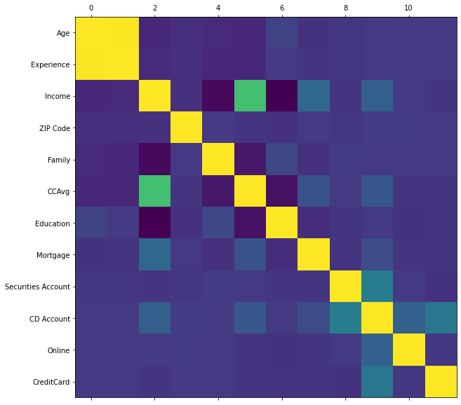

```python
def plot_corr(df):
    corr = df.corr()
    fig, ax = plt.subplots(figsize=(10, 10))
    ax.matshow(corr)
    plt.yticks(range(len(corr.columns)), corr.columns)
plot_corr(dataset.drop(['Personal Loan', 'ID'], axis='columns'))
```

#### Check distinct value counts

```python
dataset.apply(lambda x: len(x.unique()))
```

```
ID                    5000
Age                     45
Experience              47
Income                 162
ZIP Code               467
Family                   4
CCAvg                  108
Education                3
Mortgage               347
Personal Loan            2
Securities Account       2
CD Account               2
Online                   2
CreditCard               2
dtype: int64
```

#### Pair Plot of all columns

*NOTE: We can skip the ID column due to non-relevance*

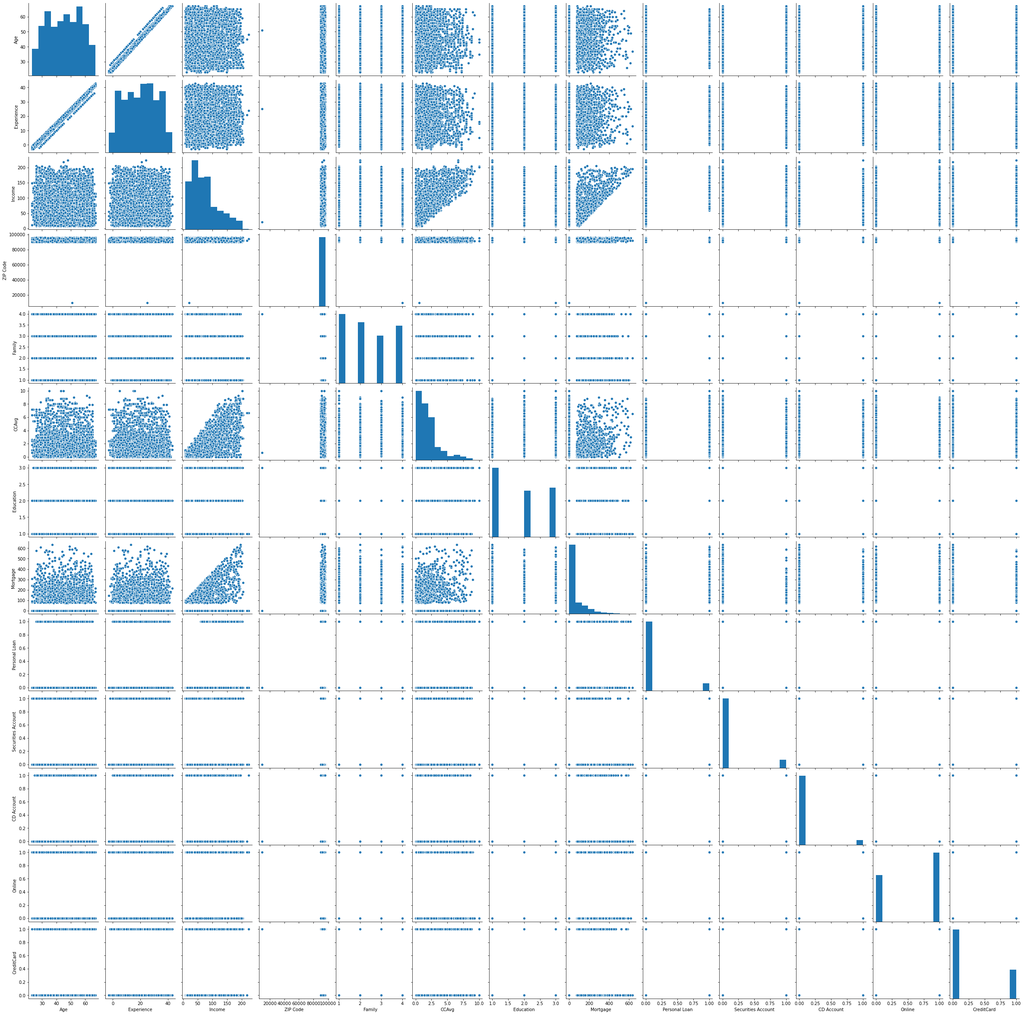

```python
sns.pairplot(dataset.iloc[:,1:])
```

*Observations around the Independent variables:-*

1. *Age* - Normally distributed, multi modal as evident from three peaks
2. *Experience* - Normally distributed. There are negative values in Experience. **Strong positive correlation with Age**
3. *Income* - Mean is greater than Median. Positively(right) skewed
4. *CCAvg* - Positively skewed because the tail goes to the right. Most of the customers monthly avg. spending on credit cards is between 1k to 2.5K. There are very few customers whose monthly avg. spending on credit card is more than 8k.
5. *Mortgage* - Heavy positive skewness. Most of the customers do not have mortgage
6. *Education* - Ordinal data. Level 1 is more than 2 and 3
7. *Family* - Ordinal data
8. *Securities Account* - Categorical(Binary) variable
9. *CD Account* - Categorical(Binary) variable
10. *Online* - Categorical(Binary) variable. Number of customers who have Online accout is geater than the number of customers who do not have online account
11. *CreditCard* - Categorical(Binary) variable. Number of people without Credit card is more than people with Credit card.
12. *ZIP Code* - Uniform distribution

#### Data Cleaning - *Fixing negative values*

```python
# Checking for the negative values in Experience column
dataset[dataset['Experience'] < 0]['Experience'].value_counts()
```

```
-1    33
-2    15
-3     4
Name: Experience, dtype: int64
```

**Observation:** There are total of 52 negative values in the Experience column of the dataset.

*We need to check again the association of Experience with other important columns. Considering Age, Income, CCAvg, Mortgage and Education here.*

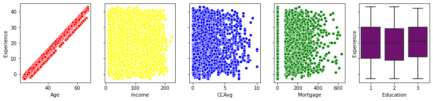

```python
X, axes = plt.subplots(1, 5, figsize=(15, 3), sharey=True)

sns.scatterplot(x='Age', y='Experience', data=dataset, color='red', ax=axes[0])
sns.scatterplot(x='Income', y='Experience', data=dataset, color='yellow', ax=axes[1])
sns.scatterplot(x='CCAvg', y='Experience', data=dataset, color='blue', ax=axes[2])
sns.scatterplot(x='Mortgage', y='Experience', data=dataset, color='green', ax=axes[3])
sns.boxplot(x='Education', y='Experience', data=dataset, color='purple', ax=axes[4])
```

**Observations** - Age has a very strong positive correlation with Experience

Since Age has a strong positive association with Experience, we can replace the negative Experience of a particular Age with the Median of Experience of that Age in the non-negative dataset

```python
df_Possitive_Experience = dataset[dataset['Experience'] > 0]
df_Negative_Experience =  dataset[dataset['Experience'] < 0]
df_Negative_Experience_List = df_Negative_Experience['ID'].tolist()

for id in df_Negative_Experience_List:
    age_values = dataset.loc[np.where(dataset['ID']==id)]["Age"].tolist()[0]
    possitive_Filtered = df_Possitive_Experience[(df_Possitive_Experience['Age'] == age_values)]
    if possitive_Filtered.empty:
        negative_Filtered = df_Negative_Experience[(df_Negative_Experience['Age'] == age_values)]
        exp = round(negative_Filtered['Experience'].median())
    else:
        exp = round(possitive_Filtered['Experience'].median())
    dataset.loc[dataset.loc[np.where(dataset['ID']==id)].index, 'Experience'] = abs(exp)
```

```python
### Checking for negative data
dataset[dataset['Experience'] < 0]['Experience'].count()
```

```
0
```

We have fixed the negative values of Experience column

## 4. Target Column distribution

```python
dataset["Personal Loan"].value_counts()
```

```
0    4520
1     480
Name: Personal Loan, dtype: int64
```

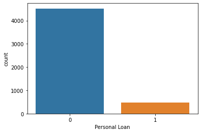

```python
sns.countplot(dataset['Personal Loan'])
```

#### Influence of important features on Personal Loan.

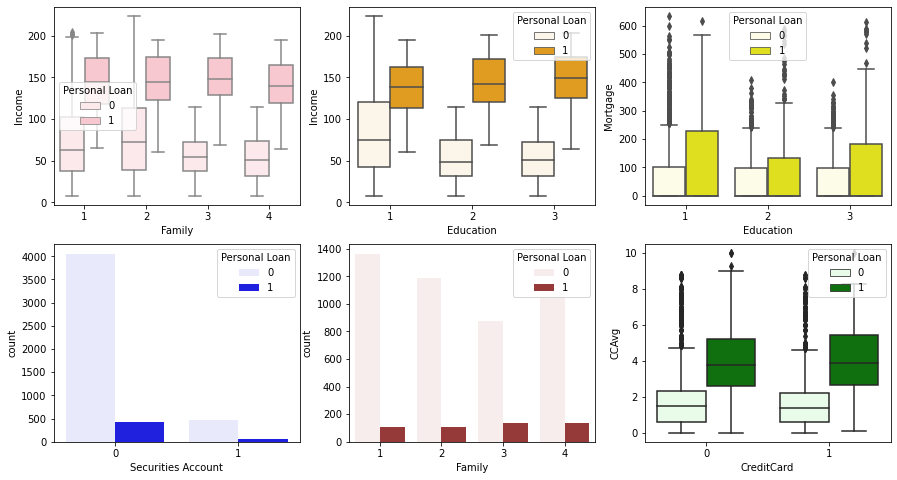

```python
X, axes = plt.subplots(2, 3, figsize=(15, 8))

sns.boxplot(x='Family', y='Income', hue='Personal Loan', data=dataset, color='pink' , ax = axes[0][0])
sns.boxplot(x='Education', y='Income', hue='Personal Loan', data=dataset, color='orange', ax = axes[0][1])
sns.boxplot(x="Education", y='Mortgage', hue='Personal Loan', data=dataset, color='yellow', ax = axes[0][2])
sns.countplot(x="Securities Account", data=dataset,hue="Personal Loan", color='blue', ax = axes[1][0])
sns.countplot(x='Family', data=dataset, hue='Personal Loan', color='brown', ax = axes[1][1])
sns.boxplot(x="CreditCard", y='CCAvg', hue="Personal Loan", data= dataset, color='green', ax = axes[1][2])
```

## 5. Dividing the data into training and testing set

```python
## We can drop Zip code since it has not impact on target variable
X = dataset.drop(['ID','ZIP Code', 'Personal Loan'], axis = 'columns')
y = dataset['Personal Loan']
X.head(1)
```

|  | Age | Experience | Income | Family | CCAvg | Education | Mortgage | Securities Account | CD Account | Online | CreditCard |
| --- | --- | --- | --- | --- | --- | --- | --- | --- | --- | --- | --- |
| 0 | 25 | 1 | 49 | 4 | 1.6 | 1 | 0 | 1 | 0 | 0 | 0 |

```python
## test size has been kept to 30%
X_train, X_test, y_train, y_test = train_test_split(X, y, test_size=0.3, random_state=1)
```

```python
print("Count of training data:", X_train.shape[0])
print("Count of testing data:", X_test.shape[0])
```

```
Count of training data: 3500
Count of testing data: 1500
```

##### Scaling the numerical columns

```python
cols_to_scale = ['Age', 'Experience', 'Income', 'CCAvg', 'Mortgage']
```

```python
scale = StandardScaler()
X_train[cols_to_scale] = scale.fit_transform(X_train[cols_to_scale])
X_test[cols_to_scale] = scale.transform(X_test[cols_to_scale])
```

```python
X_train.head(2)
```

|  | Age | Experience | Income | Family | CCAvg | Education | Mortgage | Securities Account | CD Account | Online | CreditCard |
| --- | --- | --- | --- | --- | --- | --- | --- | --- | --- | --- | --- |
| 1334 | 0.135977 | 0.153723 | -0.837058 | 2 | -0.365708 | 1 | -0.557707 | 0 | 0 | 1 | 0 |
| 4768 | -0.646212 | -0.545016 | -0.750406 | 1 | 0.037876 | 2 | -0.557707 | 0 | 0 | 1 | 0 |

```python
X_test.head(2)
```

|  | Age | Experience | Income | Family | CCAvg | Education | Mortgage | Securities Account | CD Account | Online | CreditCard |
| --- | --- | --- | --- | --- | --- | --- | --- | --- | --- | --- | --- |
| 2764 | -1.254581 | -1.331098 | 0.224429 | 1 | 0.556770 | 3 | 0.486970 | 0 | 0 | 0 | 1 |
| 4767 | -0.906941 | -0.981728 | -0.620428 | 3 | -0.596328 | 1 | 0.447173 | 1 | 0 | 0 | 0 |

## 6.Building Models

### Logistic regression

```python
log_model = LogisticRegression()
log_model.fit(X_train, y_train)
```

```
LogisticRegression(C=1.0, class_weight=None, dual=False, fit_intercept=True,
          intercept_scaling=1, max_iter=100, multi_class='warn',
          n_jobs=None, penalty='l2', random_state=None, solver='warn',
          tol=0.0001, verbose=0, warm_start=False)
```

```python
log_score_train = log_model.score(X_train, y_train)
print('Logistic Regression model score (Training Data):', log_score_train)
```

```
Logistic Regression model score (Training Data): 0.9514285714285714
```

```python
log_score = log_model.score(X_test, y_test)
print('Logistic Regression model score (Testing Data):', log_score)
```

```
Logistic Regression model score (Testing Data): 0.948
```

```python
log_pred = log_model.predict(X_test)
```

##### Confusion Matrix

```python
log_cm = confusion_matrix(y_test, log_pred)
log_cm
```

```
array([[1337,   14],
       [  64,   85]], dtype=int64)
```

```python
print('True Possitive    = ',   log_cm[1][1])
print('True Negative     = ',   log_cm[0][0])
print('False Possive     = ',   log_cm[0][1])
print('False Negative    = ',   log_cm[1][0])
```

```
True Possitive    =  85
True Negative     =  1337
False Possive     =  14
False Negative    =  64
```

```python
print("Logistic Regression - Classification Report")
print(classification_report(y_test, log_pred, labels=[1, 0]))
```

```
Logistic Regression - Classification Report
              precision    recall  f1-score   support

           1       0.86      0.57      0.69       149
           0       0.95      0.99      0.97      1351

   micro avg       0.95      0.95      0.95      1500
   macro avg       0.91      0.78      0.83      1500
weighted avg       0.94      0.95      0.94      1500
```

### KNN

```python
knn_model = KNeighborsClassifier(n_neighbors=10)
knn_model.fit(X_train, y_train)
```

```
KNeighborsClassifier(algorithm='auto', leaf_size=30, metric='minkowski',
           metric_params=None, n_jobs=None, n_neighbors=10, p=2,
           weights='uniform')
```

```python
knn_score_train = knn_model.score(X_train, y_train)
print('KNN model score (Training Data):', knn_score_train)
```

```
KNN model score (Training Data): 0.9597142857142857
```

```python
knn_score = knn_model.score(X_test, y_test)
print('KNN model score (Testing Data):', knn_score)
```

```
KNN model score (Testing Data): 0.9466666666666667
```

```python
knn_pred = knn_model.predict(X_test)
```

##### Confusion Matrix

```python
knn_cm = confusion_matrix(y_test, knn_pred)
knn_cm
```

```
array([[1350,    1],
       [  79,   70]], dtype=int64)
```

```python
print('True Possitive    = ',   knn_cm[1][1])
print('True Negative     = ',   knn_cm[0][0])
print('False Possive     = ',   knn_cm[0][1])
print('False Negative    = ',   knn_cm[1][0])
```

```
True Possitive    =  70
True Negative     =  1350
False Possive     =  1
False Negative    =  79
```

```python
print("KNN - Classification Report")
print(classification_report(y_test, knn_pred, labels=[1, 0]))
```

```
KNN - Classification Report
              precision    recall  f1-score   support

           1       0.99      0.47      0.64       149
           0       0.94      1.00      0.97      1351

   micro avg       0.95      0.95      0.95      1500
   macro avg       0.97      0.73      0.80      1500
weighted avg       0.95      0.95      0.94      1500
```

### Naive Bayes (Gaussian NB)

```python
nb_model = GaussianNB()
nb_model.fit(X_train, y_train)
```

```
GaussianNB(priors=None, var_smoothing=1e-09)
```

```python
nb_score_train = nb_model.score(X_train, y_train)
print('Naive Bayes model score (Training data):', nb_score_train)
```

```
Naive Bayes model score (Training data): 0.89
```

```python
nb_score = nb_model.score(X_test, y_test)
print('Naive Bayes model score (testing data):', nb_score)
```

```
Naive Bayes model score (testing data): 0.8746666666666667
```

```python
nb_pred = nb_model.predict(X_test)
```

##### Confusion Matrix

```python
nb_cm = confusion_matrix(y_test, nb_pred)
nb_cm
```

```
array([[1228,  123],
       [  65,   84]], dtype=int64)
```

```python
print('True Possitive    = ',   nb_cm[1][1])
print('True Negative     = ',   nb_cm[0][0])
print('False Possive     = ',   nb_cm[0][1])
print('False Negative    = ',   nb_cm[1][0])
```

```
True Possitive    =  84
True Negative     =  1228
False Possive     =  123
False Negative    =  65
```

```python
print("Naive Bayes - Classification Report")
print(classification_report(y_test, nb_pred, labels=[1, 0]))
```

```
Naive Bayes - Classification Report
              precision    recall  f1-score   support

           1       0.41      0.56      0.47       149
           0       0.95      0.91      0.93      1351

   micro avg       0.87      0.87      0.87      1500
   macro avg       0.68      0.74      0.70      1500
weighted avg       0.90      0.87      0.88      1500
```

## 7. Model Comparison and Conclusion

##### Comparing overall accurancy

```python
scores = [log_score, knn_score, nb_score]
score_leg=['log_score', 'knn_score', 'nb_score']
scores_train = [log_score_train, knn_score_train, nb_score_train]
scores
```

```
[0.948, 0.9466666666666667, 0.8746666666666667]
```

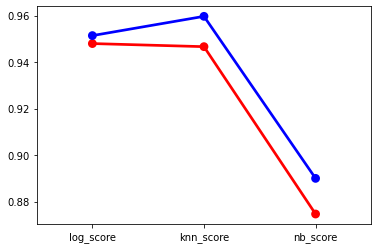

```python
sns.pointplot(score_leg, scores, color = 'red')
sns.pointplot(score_leg, scores_train, color ='blue')
```

*The overall accuracy of the Logistic regression and KNN is quite close. But the Test accuracy of Logistic regression is higher (slightly) and the difference between Training and Test data accuracy is narrow.*

##### Comparing ROC curve/score

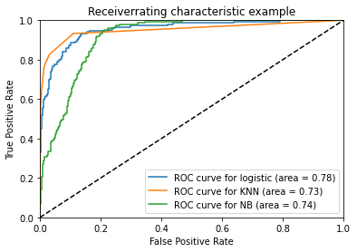

```python
plt.clf()
logit_roc_auc = roc_auc_score(y_test, log_pred)
knn_roc_auc = roc_auc_score(y_test, knn_pred)
nb_roc_auc = roc_auc_score(y_test, nb_pred)
fpr1, tpr1, thresholds1 = roc_curve(y_test, log_model.predict_proba(X_test)[:,1])
fpr2, tpr2, thresholds2 = roc_curve(y_test, knn_model.predict_proba(X_test)[:,1])
fpr3, tpr3, thresholds3 = roc_curve(y_test, nb_model.predict_proba(X_test)[:,1])
plt.plot(fpr1, tpr1, label='ROC curve for logistic (area = %0.2f)' % logit_roc_auc)
plt.plot(fpr2, tpr2, label='ROC curve for KNN (area = %0.2f)' % knn_roc_auc)
plt.plot(fpr3, tpr3, label='ROC curve for NB (area = %0.2f)' % nb_roc_auc)
plt.plot([0, 1], [0, 1], 'k--')
plt.xlim([0.0, 1.0])
plt.ylim([0.0, 1.0])
plt.xlabel('False Positive Rate')
plt.ylabel('True Positive Rate')
plt.title('Receiverrating characteristic example')
plt.legend(loc="lower right")
plt.show()
```

*Higher the AUC, more preferred the model is. In the above plot, it appears that the AUC for Logistic regression is the best here.*

##### Comparing Precision, Recall and F1 score

#### Precision

When a positive value is predicted, how often is the prediction correct?

```python
prec_log = (log_cm[1][1])/(log_cm[1][1] + log_cm[0][1])
prec_knn = (knn_cm[1][1])/(knn_cm[1][1] + knn_cm[0][1])
prec_nb = (nb_cm[1][1])/(nb_cm[1][1] + nb_cm[0][1])
print('Precision for Logistic regression :', round(prec_log,2))
print('Precision for KNN                 :', round(prec_knn,2))
print('Precision for Naive Bayes         :', round(prec_nb,1))
```

```
Precision for Logistic regression : 0.86
Precision for KNN                 : 0.99
Precision for Naive Bayes         : 0.4
```

#### Recall

When the actual value is positive, how often is the prediction correct?

```python
rec_log = (log_cm[1][1])/(log_cm[1][1] + log_cm[1][0])
rec_knn = (knn_cm[1][1])/(knn_cm[1][1] + knn_cm[1][0])
rec_nb = (nb_cm[1][1])/(nb_cm[1][1] + nb_cm[1][0])
print('Recall for Logistic regression :', round(rec_log, 2))
print('Recall for KNN                 :', round(rec_knn, 2))
print('Recall for Naive Bayes         :', round(rec_nb, 2))
```

```
Recall for Logistic regression : 0.57
Recall for KNN                 : 0.47
Recall for Naive Bayes         : 0.56
```

#### F1 score

F1 score is the Harmonic mean of Precision and Recall

```python
F1_log = 2*(prec_log*rec_log)/(prec_log + rec_log)
F1_knn = 2*(prec_knn*rec_knn)/(prec_knn + rec_knn)
F1_nb = 2*(prec_nb*rec_nb)/(prec_nb + rec_nb)
print('F1 score for Logistic regression :', round(F1_log, 2))
print('F1 score for KNN                 :', round(F1_knn, 2))
print('F1 score for Naive Bayes         :', round(F1_nb, 2))
```

```
F1 score for Logistic regression : 0.69
F1 score for KNN                 : 0.64
F1 score for Naive Bayes         : 0.47
```

#### Final thoughts:-

As shown in the plot above the **Logistic Regression** is the best model to use for this dataset. We should prefer this because:-

1. The accuracy score of the Training data set is very close to the accuracy score of the testing data set. This ensures stability of the model for unknown data.
2. The ROC-AUC is also the best for this model.
3. The precision and recall accuracy scores are high.
4. Best F1 score

For KNN, there is a small difference in the Training and test set accuracy. The Precision value is very high but recall is lower than Logistic regression and also the overall F1 score is lesser. The ROC area under the curve is the least here as well.

For Naive Bayes, the overall accuracy is less as compared to other two algorithms. The precision is very low although the recall value is similar to Logistic regression. The overall F1 score is the least.